# Mini L3 phon meta-analysis

## Brief Discussion

These results suggest that the VOT studies done with L3 learners are largely inconclusive. Much larger samples are needed (likely n > 80 per group). A larger sample ought to provide evidence that L3 learners at least have two reliably separate distributions of VOT values that could represent underlying language-specific categories. Without this criterion as a starting point, there is not reasonable support to evaluate the predictions of L3 models.

The figure below demonstrates that the plausible Bayesian estimates of effect sizes per language pairing vary greatly. The vertical, dashed lines represent small, medium and large effect sizes as standardized mean differences (.4 = small, .7 = medium, 1 = large; Plonsky & Oswald, 2014).

As can be seen in the figure, the distribution of plausible effect sizes includes 0, small effects, medium effects, and some large effects. As a result, it is difficult to make clear and categorical conclusions based on this data.

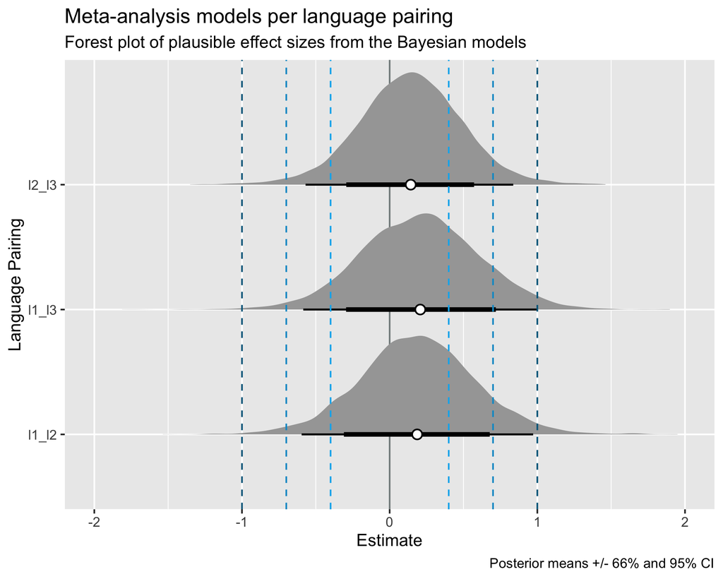